# Your Representatives

Name

Position

Party

Email

Phone

Photo

[Joseph R. Biden](https://www.whitehouse.gov/)

President of the United States

Democratic Party

Not Available

(202) 456-1111

Not Available

[Kamala D. Harris](https://www.whitehouse.gov/)

Vice President of the United States

Democratic Party

Not Available

(202) 456-1111

Not Available

[Maria Cantwell](https://www.cantwell.senate.gov/)

U.S. Senator

Democratic Party

Not Available

(202) 224-3441

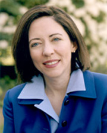

[Patty Murray](https://www.murray.senate.gov/public/)

U.S. Senator

Democratic Party

Not Available

(202) 224-2621

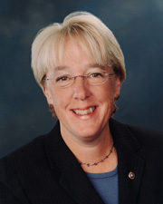

[Pramila Jayapal](https://jayapal.house.gov/)

U.S. Representative

Democratic Party

Not Available

(202) 225-3106

[figure not shown]

[Jay Inslee](https://www.governor.wa.gov/)

Governor of Washington

Democratic Party

Governor.JayInslee@governor.wa.gov

(360) 902-4111

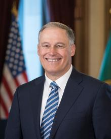

[Denny Heck](https://www.ltgov.wa.gov/)

Lieutenant Governor of Washington

Democratic Party

ltgov@ltgov.wa.gov

(360) 786-7700

Not Available

[Kim Wyman](https://www.sos.wa.gov/)

WA Secretary of State

Republican Party

secretaryofstate@sos.wa.gov

(360) 902-4151

Not Available

[Chris Reykdal](https://www.k12.wa.us/about-ospi/superintendent-chris-reykdal)

WA State Superintendent of Public Instruction

Nonpartisan

Not Available

(360) 725-6000

Not Available

[Hilary S. Franz](https://www.dnr.wa.gov/)

WA Commissioner of Public Lands

Democratic Party

cpl@dnr.wa.gov

(360) 902-1000

Not Available

[Mike Pellicciotti](https://www.tre.wa.gov/)

WA State Treasurer

Democratic Party

Not Available

(360) 902-9001

Not Available

[Pat McCarthy](https://www.sao.wa.gov/)

WA State Auditor

Democratic Party

Not Available

(564) 999-0950

Not Available

[Bob Ferguson](https://www.atg.wa.gov/about-bob-ferguson)

WA Attorney General

Democratic Party

Not Available

(360) 753-6200

Not Available

[Mike Kreidler](https://www.insurance.wa.gov/about-mike-kreidler)

WA Insurance Commissioner

Democratic Party

askmike@oic.wa.gov

(360) 725-7000

Not Available

[Barbara A. Madsen](https://www.courts.wa.gov/appellate_trial_courts/SupremeCourt/?fa=supremecourt.justices)

WA Supreme Court Justice

Nonpartisan

supreme@courts.wa.gov

(360) 357-2037

Not Available

[Charles W. Johnson](https://www.courts.wa.gov/appellate_trial_courts/SupremeCourt/?fa=supremecourt.justices)

WA Supreme Court Justice

Nonpartisan

supreme@courts.wa.gov

(360) 357-2020

Not Available

[Debra L. Stephens](https://www.courts.wa.gov/appellate_trial_courts/SupremeCourt/?fa=supremecourt.justices)

WA Supreme Court Justice

Nonpartisan

supreme@courts.wa.gov

(360) 357-2050

Not Available

[G. Helen Whitener](https://www.courts.wa.gov/appellate_trial_courts/SupremeCourt/?fa=supremecourt.justices)

WA Supreme Court Justice

Nonpartisan

supreme@courts.wa.gov

(360) 357-2026

Not Available

[Mary I. Yu](https://www.courts.wa.gov/appellate_trial_courts/SupremeCourt/?fa=supremecourt.justices)

WA Supreme Court Justice

Nonpartisan

mary.yu@courts.wa.gov

(360) 357-2033

Not Available

[Raquel Montoya-Lewis](https://www.courts.wa.gov/appellate_trial_courts/SupremeCourt/?fa=supremecourt.justices)

WA Supreme Court Justice

Nonpartisan

supreme@courts.wa.gov

(360) 357-2054

Not Available

[Sheryl Gordon McCloud](https://www.courts.wa.gov/appellate_trial_courts/SupremeCourt/?fa=supremecourt.justices)

WA Supreme Court Justice

Nonpartisan

supreme@courts.wa.gov

(360) 357-2045

Not Available

[Steven C. González](https://www.courts.wa.gov/appellate_trial_courts/SupremeCourt/?fa=supremecourt.justices)

WA Supreme Court Justice

Nonpartisan

supreme@courts.wa.gov

(360) 357-2030

Not Available

[Susan Owens](https://www.courts.wa.gov/appellate_trial_courts/SupremeCourt/?fa=supremecourt.justices)

WA Supreme Court Justice

Nonpartisan

supreme@courts.wa.gov

(360) 357-2041

Not Available

[Dow Constantine](https://www.kingcounty.gov/elected/executive/constantine.aspx)

King County Executive

Nonpartisan

kcexec@kingcounty.gov

(206) 263-9600

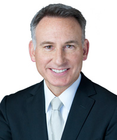

[Julie Wise](https://www.kingcounty.gov/depts/elections.aspx)

King County Elections Director

Nonpartisan

elections@kingcounty.gov

(206) 477-4140

Not Available

[John Wilson](https://www.kingcounty.gov/depts/assessor.aspx)

King County Assessor

Nonpartisan

assessor.info@kingcounty.gov

(206) 296-7300

Not Available

[Mitzi Johanknecht](https://www.kingcounty.gov/depts/sheriff.aspx)

King County Sheriff

Nonpartisan

sheriff@kingcounty.gov

(206) 296-4155

Not Available

[Dan Satterberg](https://www.kingcounty.gov/depts/prosecutor.aspx)

King County Prosecuting Attorney

Nonpartisan

prosecuting.attorney@kingcounty.gov

(206) 477-1200

Not Available

[Jenny Durkan](https://www.seattle.gov/mayor)

Mayor of Seattle

Nonpartisan

jenny.durkan@seattle.gov

(206) 684-4000

Not Available

[Pete Holmes](https://www.seattle.gov/cityattorney)

Seattle City Attorney

Nonpartisan

peter.holmes@seattle.gov

(206) 684-8200

Not Available

[M. Lorena González](https://www.seattle.gov/council/gonzalez)

Seattle City Council Member

Nonpartisan

lorena.gonzalez@seattle.gov

(206) 684-8888

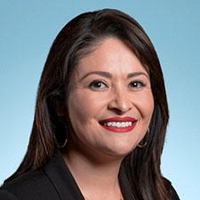

[Teresa Mosqueda](https://www.seattle.gov/council/mosqueda)

Seattle City Council Member

Nonpartisan

teresa.mosqueda@seattle.gov

(206) 684-8888

Not Available

# House of Representatives

Now let’s take a look at all of the congressional representatives (in the House of Representatives, not the Senate) for the state in which the address was given. We see this breakdown by gender and political party for those members of the House:

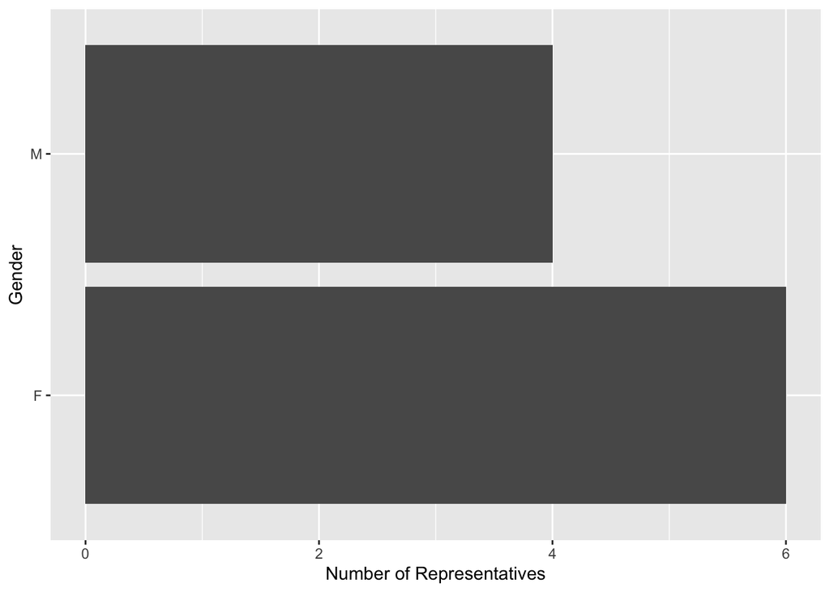

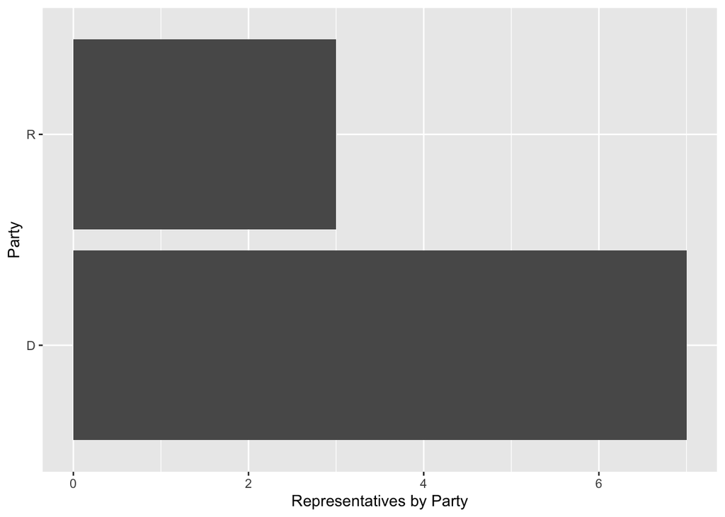

# Rick Larsen

Let’s learn a bit more about one representative, Rick Larsen. The representative is 56 years old, and you can find them on Twitter at RepRickLarsen. Interestingly, of the last 20 congressional votes, the representative was in accordance with the majority 80 percent of the time.